# Working with the Posterior

Let’s once again use the language of machine learning to breakdown the traditional Bayesian problem description again:

- You are training a probability model on random variables X and θ. Everything that we observe in the training data is called X. Everything we do not observe is called a “parameter,” which we name θ. θ subsumes ideas like “weights” and “latent variables.”
- You specify a distribution for components of θ in your model. In Stan, you do this in the model block. For θ, these distribution functions are called priors, and for X, they are called likelihood functions.
- Your training procedure targets the posterior distribution P(θ|X). There are analytic ways to calculate the posterior as a canonical distribution. But in the general case, we use an algorithm to sample from the posterior. Without a canonical representation of the posterior, our understanding of the posterior relies completely on samples.

Consider that fundamental mismatch; Stan and most other probabilistic modeling frameworks require canonical priors but only give you samples from the posterior.

## Reasoning on the posterior

We phrase almost all the questions you want to ask in Bayesian inference as the posterior expectation of a function over θ.

$$E(f(\theta) | X) = \int f(\theta)\pi(\theta |X)d\theta$$

For example, suppose you are interested in a point estimate of θ. Then f(.) is just the identity, and you get the posterior mean.

$$E(\theta| X) = \int \theta\pi(\theta |X)d\theta$$
Suppose instead you want other descriptions of the posterior. An example is posterior variance.

$$\begin{align*}
var(\theta| X) &= E(\theta^2|X) - E(\theta|X)^2 \\
&= \int \theta^2 \pi(\theta |X) d \theta - E(\theta|X)
\end{align*}$$

Percentiles are a bit trickier. Suppose you want to calculate a 95% credible interval (Bayesian alternative to a confidence interval). You need the 2.5% and 97.5% percentiles. To calculate the 2.5% and 97.5% percentiles, you to solve the following equations:

$$\begin{align*}
E(I(\theta \leq a)|X) = .025; \text{solve for a} \\
E(I(\theta \geq b)|X) = .975; \text{solve for b} \\
\end{align*}$$

Note that Stan [provides a function](https://mc-stan.org/docs/2_25/functions-reference/functions-algebraic-solver.html) for finding algebraic solutions.

### Technical note: Posterior mode is poorly defined.

The *mode* of a distribution is the value that has the highest posterior probability mass or density; in Bayesian terms, we call it the [maximum a posteriori estimation](https://en.wikipedia.org/wiki/Maximum_a_posteriori_estimation). But we don’t know that function; we only have samples from it.

One thing you can do is take the sample with the highest product of likelihood and prior probability. Or you could [fit a kernel density function](https://en.wikipedia.org/wiki/Kernel_density_estimation) to the samples and finding the mode of this function. But this is not the true mode of the posterior.

## Monte Carlo estimation of posterior expectation

Given samples from $\pi(\theta|X)$, our goal is to estimate $E(f(X)|\theta)$. We do this by applying $f(.)$ to every sample and taking the mean. Monte Carlo estimation theory guarantees that as the number of samples goes to infinity, the sample mean will converge to the true expectation.

## Loss functions and posterior risk

The most practically useful functions help us make decisions under uncertainty. [Bayesian decision theory](https://en.wikipedia.org/wiki/Bayes_estimator) defines loss functions that quantify some cost resulting from undesirable parameter values. We make decisions that minimize the posterior expectation of these loss functions.

## Estimating posterior expectation in Stan

```r
library(rstan)
library(tidyverse)
library(tidybayes)
```

Revisiting the height and weight example, let’s estimate $f(b) = b^2$. Stan has a `generated quantities` block where we apply these functions to parameter values.

```
generated quantities {
  real b_squared;
  b_squared = b * b;
}
```

```r
model_data <- read_delim("https://raw.githubusercontent.com/altdeep/probmodeler/main/tutorials/data/height_weight_age_male.csv", delim = ";") %>%
  filter(age >= 18) %>%
  select(height, weight) %>%
  compose_data

stan_program_code <- '
data {
  int<lower=1> n;
  vector[n] height;
  vector[n] weight;
}
parameters {
  real<lower=0,upper=50> sigma;
  real<lower=0> b;
  real a;
}
transformed parameters {
  vector[n] mu;
  mu = a + b * weight;
}
model {
  a ~ normal(178, 20);
  b ~ lognormal(0, 1);
  sigma ~ uniform(0, 50);
  weight ~ normal(100, 10);
  height ~ normal(mu, sigma);
}
generated quantities {
  real b_squared;
  b_squared = b * b;
}
'
compiled_program <- stan_model(model_code = stan_program_code)
posterior <- sampling(object = compiled_program, data=model_data)
```

Now we can access `b_squared` samples from the sampling output.

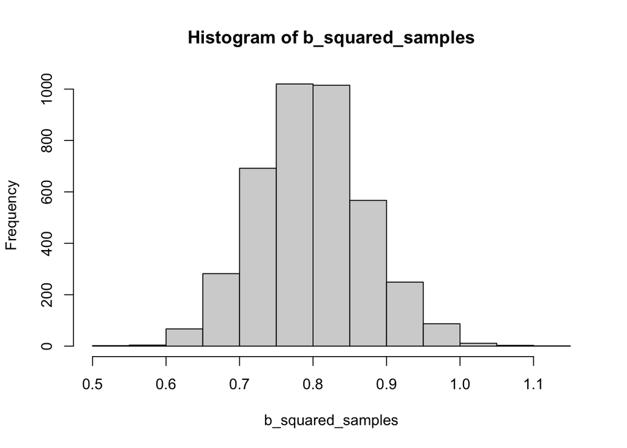

```r
b_samples <- rstan::extract(posterior)['b']$b
b_squared_samples <- rstan::extract(posterior)['b_squared']$b_squared
hist(b_squared_samples)
```

We estimate $E(b^2|\text{height}, \text{weight})$ simply by taking the mean.

```r
mean(b_squared_samples)
```

```
## [1] 0.7976127
```

Among other things, we can use this to calculate posterior variance. For a random variable $Y$, $\text{var}{Y} = E((Y - E(Y))^2)$, which decomposes into $E(Y^2) - E(Y)^2$. We can estimate each of those expectations separately, and combine them.

```r
mean(b_squared_samples) - mean(b_samples)^2
```

```
## [1] 0.001707894
```

Of course, we can simply calculate our estimate as the sample variance.

```r
var(b_samples)
```

```
## [1] 0.001708321
```

The point is, we can apply a function to each sample, then take the mean of the results. Stan’s `generated quantities` block makes this easy for us.